# Enhancing Student and Teacher Agency in Knowledge Building with AI

Bodong Chen

cbd@upenn.edu • bchen.net

Associate Professor, University of Pennsylvania

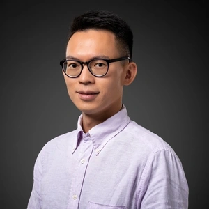

## Knowledge Building

**A constellation of perspectives** involving students working as a community to continually improve ideas

- **Agents** with epistemic agency
- **Artifacts** created & refined
- **Practices** for idea improvement

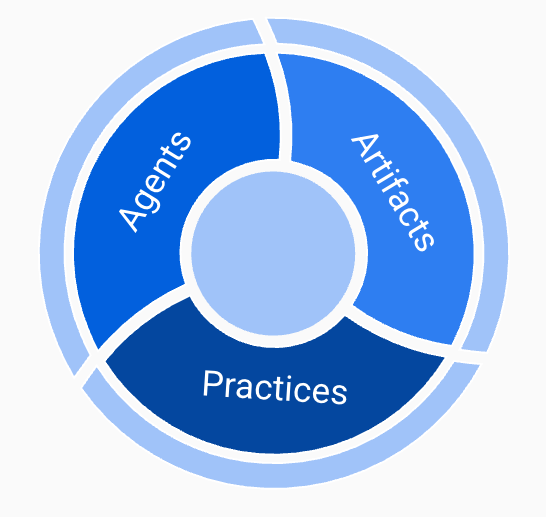

(Chan & Aalst, 2018; Chen & Hong, 2016; Scardamalia & Bereiter, 2022)

## Technology for Knowledge Building

**Knowledge Forum**  
Digital environment for continual idea improvement

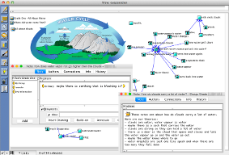

**KB Wall**  
Physical manifestation of collaborative knowledge work

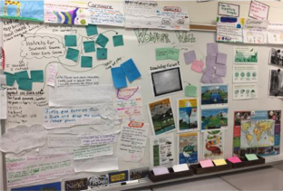

## Essential KB Principles

1. **Epistemic Agency**: Students have high-level agency over *what* they want to know and *how* they arrive at knowledge
2. **Knowledge-Creating Dialogue**: Carried out through dialogues that differ from teacher-centered discourse
3. **Transformative Assessment**: Assess state of the art and feed-forward to potential progress—like people working at the knowledge frontier

How can AI uphold these principles rather than undermine them?

(Scardamalia, 2002)

## Two Examples: AI Supporting Agency

**1: Integrate AI in *student* dialogues**  
to support student epistemic agency

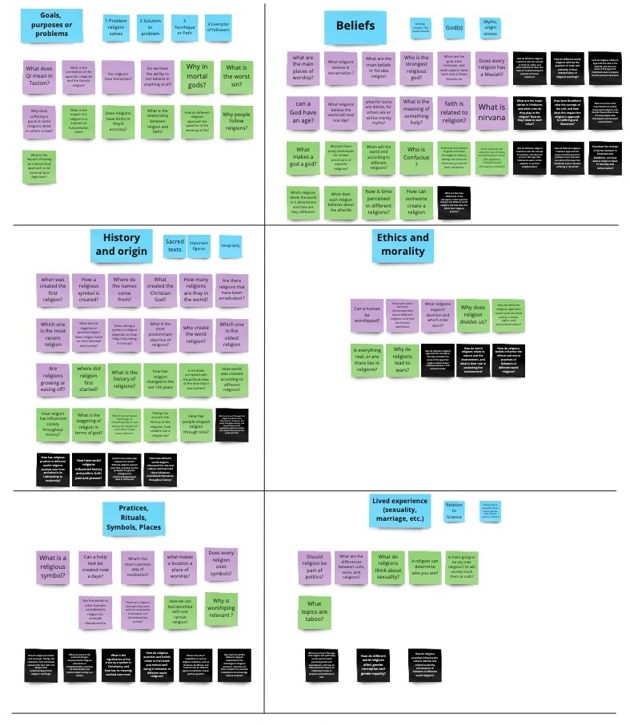

**2: CraftPad for *teacher* design**  
to support teacher agency in design

[figure not shown]

## Case 1: AI in Student KB Dialogues

**Context**

- High school World Religions course
- Taught by one experienced KB teacher
- Multiple digital tools (KF, Miro, ChatGPT)

**Design Question** How to distribute agency between students and AI?

**Co-Design with Teacher**

Situate AI in Knowledge-Creating Dialogue Moves:

- Problem definition
- New ideas
- Promisingness evaluation
- Meta-dialogue
- Comparison
- Critical discourse
- Higher-level ideas

(Bereiter & Scardamalia, 2017)

## Two Patterns of ChatGPT Integration

**Pattern 1**: Explore Problem Space

**Pattern 2**: Build Through Discourse

[figure not shown]

## Key Finding: AI Made Learning Harder and Deeper

**Students Demonstrated AI Literacy**

- Understood mechanisms & limitations
- Recognized need for fact-checking
- Saw risks of over-dependence
- Maintained critical stance

**Students Took High-Level Agency**

- Used AI for inspiration, not answers
- Engaged in prompt design
- Collaborated more, not less, with peers

🦉 **By maintaining epistemic agency, students learned *about* AI, and learned how to learn *with* AI**

(Tan et al., 2025)

## Case 2: CraftPad for Teacher Design

**Goals**

Support teachers as designers with professional agency

- **Flexible workspace with pedagogical scaffolding**

[figure not shown]

## Case 2: CraftPad for Teacher Design

**Goals**

Support teachers as designers with professional agency

- Flexible workspace with pedagogical scaffolding
- **Context-aware KB Coach**

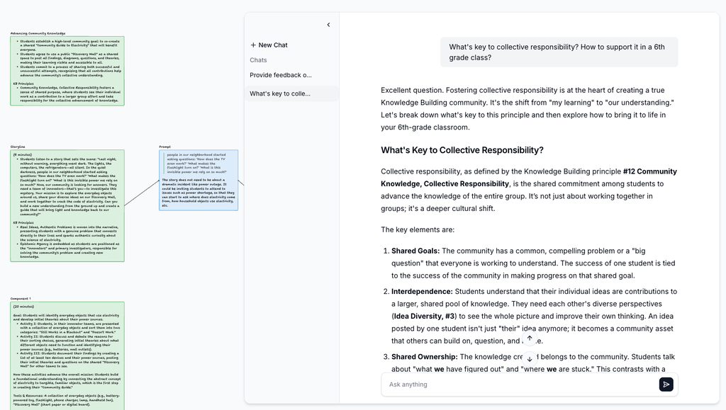

## Case 2: CraftPad for Teacher Design

**Goals**

Support teachers as designers with professional agency

- Flexible workspace with pedagogical scaffolding
- Context-aware KB Coach
- **Rich opportunities for teacher decisions**

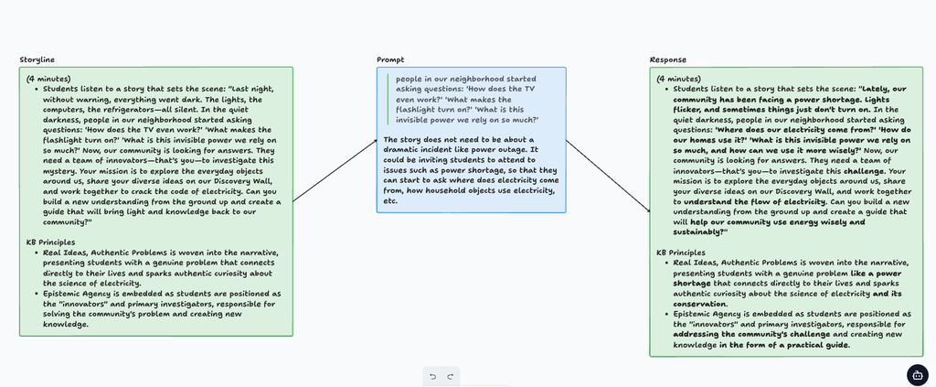

## CraftPad: Preliminary Findings

**Design Activity** (from 52 users)

- Shows deep iterative refinement
- Some with up to **96 revisions**

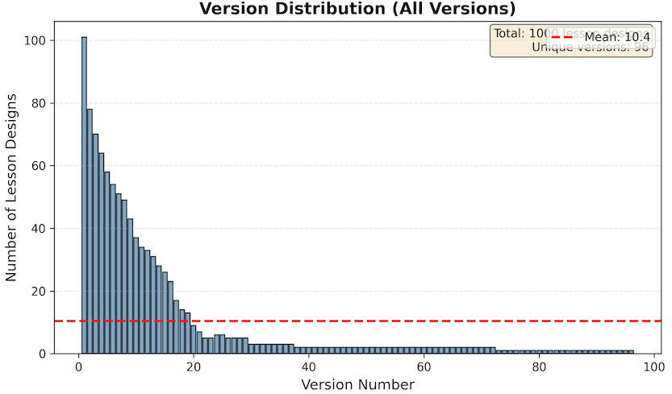

**KB Coach Conversations**

- Most were consultations focused on *refining lesson designs*
- Some focused on certain KB principles
- A few went deep (e.g., 38 messages exploring SDG connections in a photosynthesis unit)

Teachers are *designing* with AI, not just consuming AI-generated content

## Integrate AI in KB Classrooms

**Students + AI**

- AI aligned with dialogue moves
- Students maintained epistemic agency
- Learning became harder (deeper)
- More collaboration, not less

**Teachers + AI**

- AI positioned as design coach
- Teachers maintained professional agency
- Design became more iterative
- More reflection, not less

**Design for high-level human agency**. **AI as flashlight**, not magic.

# Thank you!

**Bodong Chen** cbd@upenn.edu  
https://penn-wonderlab.github.io/

**Acknowledgement** Jiayu Cheng, Vivian Leung, Yue Zhao (University of Pennsylvania); Xinran Zhu (UIUC); Fernando Díaz del Castillo (Mentu/Gimnasio La Montaña)